# Analiza cen wynajmu mieszkań w Szczecinie

## Celem projektu jest prosta analiza ofert wynajmu mieszkań w Szczecinie na podstawie danych z okresu listopad 2023 - czerwiec 2024.

### Projekt został wykonany na potrzeby kursu Analiza Danych z Pythonem

### Autor projektu: Kacper Karnath

## Import wymaganych bibliotek

```python
import pandas as pd
import matplotlib.pyplot as plt
import seaborn as sns
```

## Przygotowanie listy plików z danymi

```python
dane = [
    ("Dane/apartments_rent_pl_2023_11.csv", "2023-11"),
    ("Dane/apartments_rent_pl_2023_12.csv", "2023-12"),
    ("Dane/apartments_rent_pl_2024_01.csv", "2024-01"),
    ("Dane/apartments_rent_pl_2024_02.csv", "2024-02"),
    ("Dane/apartments_rent_pl_2024_03.csv", "2024-03"),
    ("Dane/apartments_rent_pl_2024_04.csv", "2024-04"),
    ("Dane/apartments_rent_pl_2024_05.csv", "2024-05"),
    ("Dane/apartments_rent_pl_2024_06.csv", "2024-06")
]
```

## Wczytanie i połączenie danych

```python
lista_danych = []

for plik, miesiac in dane:
    dane_miesiac = pd.read_csv(plik)
    dane_miesiac["month"] = miesiac
    lista_danych.append(dane_miesiac)

df = pd.concat(lista_danych, ignore_index=True)

df.head(10)
```

|  | id | city | type | squareMeters | rooms | floor | floorCount | buildYear | latitude | longitude | ... | ownership | buildingMaterial | condition | hasParkingSpace | hasBalcony | hasElevator | hasSecurity | hasStorageRoom | price | month |
| --- | --- | --- | --- | --- | --- | --- | --- | --- | --- | --- | --- | --- | --- | --- | --- | --- | --- | --- | --- | --- | --- |
| 0 | 2a1a6db97ff122d6bc148abb6f0e498a | szczecin | blockOfFlats | 52.00 | 2.0 | 3.0 | 3.0 | 2008.0 | 53.460535 | 14.545416 | ... | condominium | brick | NaN | yes | yes | no | no | no | 3500 | 2023-11 |
| 1 | 5a0cb42c088eadf75aa98a4118640048 | szczecin | blockOfFlats | 57.00 | 3.0 | NaN | 10.0 | 1976.0 | 53.440955 | 14.566024 | ... | condominium | NaN | premium | no | yes | yes | no | no | 3000 | 2023-11 |
| 2 | 996722490efcb4b34d48bb84a9a72838 | szczecin | NaN | 43.40 | 2.0 | 3.0 | 4.0 | NaN | 53.435746 | 14.560764 | ... | condominium | NaN | NaN | no | yes | no | no | no | 1900 | 2023-11 |
| 3 | 50d75c688530b9a61ba505301e0b94a9 | szczecin | apartmentBuilding | 32.60 | 2.0 | 5.0 | 6.0 | 2021.0 | 53.421582 | 14.541572 | ... | condominium | brick | premium | no | yes | yes | no | no | 2500 | 2023-11 |
| 4 | 9b187f4203adabf466fd08610d8f4e5e | szczecin | apartmentBuilding | 72.00 | 3.0 | 6.0 | 6.0 | 2014.0 | 53.450010 | 14.547230 | ... | condominium | brick | premium | no | yes | yes | no | yes | 2999 | 2023-11 |
| 5 | ba4d70d65d1024ee13929ca82bfc92f6 | szczecin | blockOfFlats | 52.00 | 2.0 | 1.0 | 3.0 | 2006.0 | 53.427400 | 14.488100 | ... | condominium | concreteSlab | NaN | yes | no | no | no | no | 2300 | 2023-11 |
| 6 | 195bf5124c9fd720ca3ff7aeff9ca83f | szczecin | blockOfFlats | 45.94 | 2.0 | 4.0 | 10.0 | 1978.0 | 53.433567 | 14.539891 | ... | condominium | concreteSlab | NaN | no | yes | yes | no | no | 2500 | 2023-11 |
| 7 | 03a41e8ec8ebdc1dd5a86d65ae3de54e | szczecin | blockOfFlats | 54.00 | 2.0 | NaN | 3.0 | 2002.0 | 53.412600 | 14.541100 | ... | condominium | brick | premium | yes | yes | yes | no | yes | 2600 | 2023-11 |
| 8 | aae4994ab375e107dcc375f3360bd3d9 | szczecin | tenement | 32.00 | 1.0 | 2.0 | 4.0 | 1930.0 | 53.434836 | 14.548864 | ... | condominium | brick | premium | no | no | NaN | no | no | 1500 | 2023-11 |
| 9 | b83458393eb79b3ecdb13de56a6e2676 | szczecin | blockOfFlats | 76.38 | 3.0 | 1.0 | 1.0 | 1954.0 | 53.435478 | 14.512039 | ... | condominium | brick | premium | yes | no | no | no | no | 3600 | 2023-11 |

10 rows × 29 columns

Połączono dane z kilku plików miesięcznych w jeden zbiór danych. Dodano również kolumnę "month", która pozwala określić, z którego miesiąca pochodzi dana oferta. Dzięki temu możliwa jest późniejsza analiza zmian liczby ofert i cen w czasie.

## Sprawdzenie rozmiaru danych, liczby wierszy i kolumn

```python
df.shape
```

```
(70847, 29)
```

# Podstawowe informacje o danych

```python
df.info()
```

```
<class 'pandas.core.frame.DataFrame'>
RangeIndex: 70847 entries, 0 to 70846
Data columns (total 29 columns):
 #   Column                Non-Null Count  Dtype
---  ------                --------------  -----
 0   id                    70847 non-null  object
 1   city                  70847 non-null  object
 2   type                  54085 non-null  object
 3   squareMeters          70847 non-null  float64
 4   rooms                 70847 non-null  float64
 5   floor                 62234 non-null  float64
 6   floorCount            69468 non-null  float64
 7   buildYear             51165 non-null  float64
 8   latitude              70847 non-null  float64
 9   longitude             70847 non-null  float64
```

[output cut: 21 more lines]

Dane mają 70847 wierszy i 29 kolumn. Na tym etapie widać, że część kolumn posiada braki danych, np. `type`, `floor` i inne. Braki zostaną dokładniej sprawdzone w dalszej części projektu.

## Sprawdzenie nazw kolumn

```python
df.columns
```

```
Index(['id', 'city', 'type', 'squareMeters', 'rooms', 'floor', 'floorCount',
       'buildYear', 'latitude', 'longitude', 'centreDistance', 'poiCount',
       'schoolDistance', 'clinicDistance', 'postOfficeDistance',
       'kindergartenDistance', 'restaurantDistance', 'collegeDistance',
       'pharmacyDistance', 'ownership', 'buildingMaterial', 'condition',
       'hasParkingSpace', 'hasBalcony', 'hasElevator', 'hasSecurity',
       'hasStorageRoom', 'price', 'month'],
      dtype='object')
```

W danych znajdują się informacje między innymi o mieście, cenie, metrażu, liczbie pokoi, piętrze, roku budowy, odległościach od różnych punktów oraz dodatkowych cechach mieszkania.

## Sprawdzenie dostępnych miast

```python
df["city"].value_counts()
```

```
city
warszawa       28414
krakow         12661
wroclaw         6676
lodz            5214
poznan          3890
gdansk          3595
katowice        2669
gdynia          1483
szczecin        1482
bydgoszcz       1478
lublin          1313
czestochowa      661
rzeszow          614
bialystok        440
radom            257
Name: count, dtype: int64
```

Najwięcej ofert znajduje się w Warszawie oraz Krakowie, najmniej w Częstochowie, Rzeszowie, Białymstoku i Radomiu.

W danych znajduje się wiele miast, do analizy wybrany został Szczecin. W danych znajduje się 1482 ofert z tego miasta.

```python
szczecin = df[df["city"] == "szczecin"].copy()

szczecin.shape
```

```
(1482, 29)
```

## Podgląd danych dla Szczecina

```python
szczecin.head()
```

|  | id | city | type | squareMeters | rooms | floor | floorCount | buildYear | latitude | longitude | ... | ownership | buildingMaterial | condition | hasParkingSpace | hasBalcony | hasElevator | hasSecurity | hasStorageRoom | price | month |
| --- | --- | --- | --- | --- | --- | --- | --- | --- | --- | --- | --- | --- | --- | --- | --- | --- | --- | --- | --- | --- | --- |
| 0 | 2a1a6db97ff122d6bc148abb6f0e498a | szczecin | blockOfFlats | 52.0 | 2.0 | 3.0 | 3.0 | 2008.0 | 53.460535 | 14.545416 | ... | condominium | brick | NaN | yes | yes | no | no | no | 3500 | 2023-11 |
| 1 | 5a0cb42c088eadf75aa98a4118640048 | szczecin | blockOfFlats | 57.0 | 3.0 | NaN | 10.0 | 1976.0 | 53.440955 | 14.566024 | ... | condominium | NaN | premium | no | yes | yes | no | no | 3000 | 2023-11 |
| 2 | 996722490efcb4b34d48bb84a9a72838 | szczecin | NaN | 43.4 | 2.0 | 3.0 | 4.0 | NaN | 53.435746 | 14.560764 | ... | condominium | NaN | NaN | no | yes | no | no | no | 1900 | 2023-11 |
| 3 | 50d75c688530b9a61ba505301e0b94a9 | szczecin | apartmentBuilding | 32.6 | 2.0 | 5.0 | 6.0 | 2021.0 | 53.421582 | 14.541572 | ... | condominium | brick | premium | no | yes | yes | no | no | 2500 | 2023-11 |
| 4 | 9b187f4203adabf466fd08610d8f4e5e | szczecin | apartmentBuilding | 72.0 | 3.0 | 6.0 | 6.0 | 2014.0 | 53.450010 | 14.547230 | ... | condominium | brick | premium | no | yes | yes | no | yes | 2999 | 2023-11 |

5 rows × 29 columns

## Sprawdzenie informacji o danych dla Szczecina

```python
szczecin.info()
```

```
<class 'pandas.core.frame.DataFrame'>
Index: 1482 entries, 0 to 62168
Data columns (total 29 columns):
 #   Column                Non-Null Count  Dtype
---  ------                --------------  -----
 0   id                    1482 non-null   object
 1   city                  1482 non-null   object
 2   type                  1174 non-null   object
 3   squareMeters          1482 non-null   float64
 4   rooms                 1482 non-null   float64
 5   floor                 1287 non-null   float64
 6   floorCount            1460 non-null   float64
 7   buildYear             1246 non-null   float64
 8   latitude              1482 non-null   float64
 9   longitude             1482 non-null   float64
```

[output cut: 21 more lines]

Po ograniczeniu danych do Szczecina w zbiorze pozostały tylko oferty z wybranego miasta. Dalsza analiza będzie prowadzona na tym podzbiorze, co pozwala uniknąć mieszania różnych rynków najmu z wielu miast.

## Sprawdzenie duplikatów

```python
szczecin.duplicated().sum()
```

```
np.int64(0)
```

Zbiór nie zawiera duplikatów.

```python
szczecin["id"].nunique()
```

```
719
```

W danych dla Szczecina znajduje się 1482 obserwacji, ale tylko 719 unikalnych identyfikatorów ofert. Oznacza to, że część ofert pojawiała się w więcej niż jednym miesiącu. Nie traktujemy tego jako błąd, ponieważ analizujemy dane z kilku miesięcy.

## Sprawdzenie braków danych

```python
braki = pd.DataFrame({
    "liczba_brakow": szczecin.isna().sum(),
    "procent_brakow": round(szczecin.isna().mean() * 100, 2)
})

braki = braki[braki["liczba_brakow"] > 0]
braki = braki.sort_values("procent_brakow", ascending=False)

braki
```

|  | liczba_brakow | procent_brakow |
| --- | --- | --- |
| condition | 550 | 37.11 |
| buildingMaterial | 362 | 24.43 |
| type | 308 | 20.78 |
| buildYear | 236 | 15.92 |
| floor | 195 | 13.16 |
| hasElevator | 156 | 10.53 |
| collegeDistance | 52 | 3.51 |
| floorCount | 22 | 1.48 |

Najwięcej braków danych występuje w kolumnach `condition`, `buildingMaterial`, `type`, `buildYear`, `floor` oraz `hasElevator`. Braki dotyczą głównie cech opisowych mieszkania i budynku.

## Heatmapa braków danych

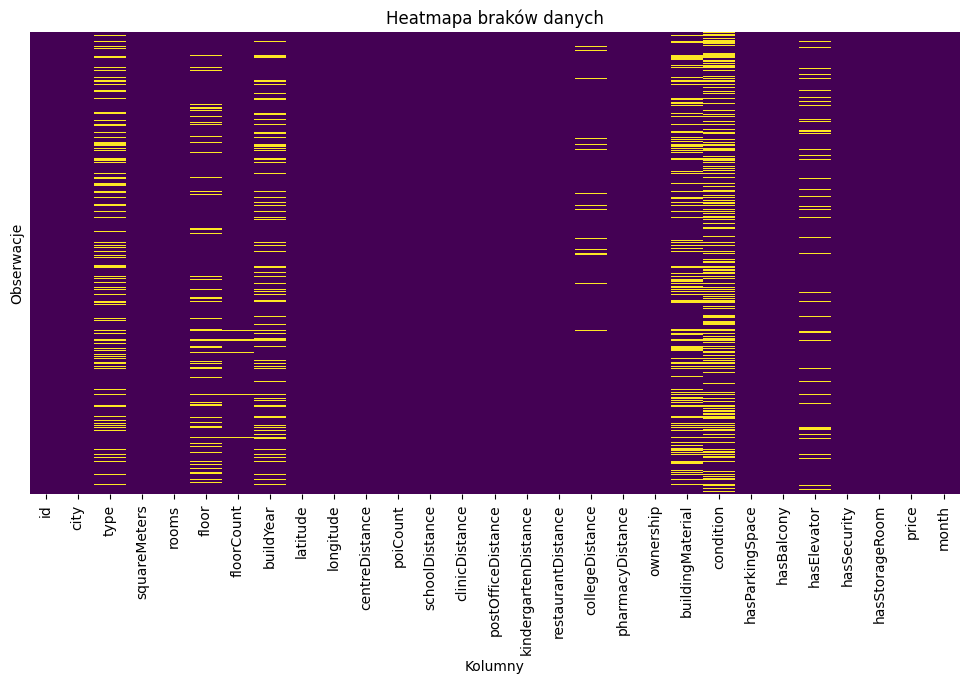

```python
plt.figure(figsize=(12, 6))

sns.heatmap(szczecin.isna(), cbar=False, yticklabels=False, cmap="viridis")

plt.title("Heatmapa braków danych")
plt.xlabel("Kolumny")
plt.ylabel("Obserwacje")

plt.show()
```

Heatmapa pozwala nam zobrazować, jak rozkładają się braki danych dla całego zbioru.

```python
szczecin[["price", "squareMeters", "rooms", "floor", "floorCount", "buildYear"]].describe()
```

|  | price | squareMeters | rooms | floor | floorCount | buildYear |
| --- | --- | --- | --- | --- | --- | --- |
| count | 1482.000000 | 1482.000000 | 1482.000000 | 1287.000000 | 1460.000000 | 1246.000000 |
| mean | 2632.659919 | 51.531242 | 2.246289 | 3.084693 | 4.976712 | 1990.968700 |
| std | 732.369461 | 19.567319 | 0.831968 | 1.970184 | 3.755481 | 32.142526 |
| min | 1300.000000 | 25.000000 | 1.000000 | 1.000000 | 1.000000 | 1897.000000 |
| 25% | 2100.000000 | 37.000000 | 2.000000 | 2.000000 | 3.000000 | 1970.000000 |
| 50% | 2500.000000 | 47.550000 | 2.000000 | 3.000000 | 4.000000 | 2004.000000 |
| 75% | 2999.750000 | 61.000000 | 3.000000 | 4.000000 | 5.000000 | 2018.000000 |
| max | 5000.000000 | 140.000000 | 6.000000 | 13.000000 | 28.000000 | 2024.000000 |

## Usunięcie ujemnych wartości, jeśli występują

```python
liczba_przed = len(szczecin)

szczecin = szczecin[szczecin["price"] > 0]
szczecin = szczecin[szczecin["squareMeters"] > 0]
szczecin = szczecin[szczecin["rooms"] > 0]

liczba_po = len(szczecin)
liczba_usunietych = liczba_przed - liczba_po

print("Liczba wierszy przed czyszczeniem:", liczba_przed)
print("Liczba wierszy po czyszczeniu:", liczba_po)
print("Liczba usuniętych wierszy:", liczba_usunietych)
```

```
Liczba wierszy przed czyszczeniem: 1482
Liczba wierszy po czyszczeniu: 1482
Liczba usuniętych wierszy: 0
```

## Uzupełnienie braków danych metodą hot deck

```python
def wypelnij_hotdeck(dane, kolumna):
    braki = dane[kolumna].isna()
    ile_brakow = braki.sum()

    if ile_brakow > 0:
        dostepne_wartosci = dane.loc[~braki, kolumna]
        wylosowane_wartosci = dostepne_wartosci.sample(
            n=ile_brakow,
            replace=True,
            random_state=42
        ).values

        dane.loc[braki, kolumna] = wylosowane_wartosci

    return dane
```

```python
szczecin.isna().sum().sum()
```

```
np.int64(1881)
```

## Wybranie kolumn z brakami danych

```python
kolumny_z_brakami = szczecin.columns[szczecin.isna().sum() > 0]

kolumny_z_brakami
```

```
Index(['type', 'floor', 'floorCount', 'buildYear', 'collegeDistance',
       'buildingMaterial', 'condition', 'hasElevator'],
      dtype='object')
```

## Uzupełnienie braków w wybranych kolumnach

```python
for kolumna in kolumny_z_brakami:
    szczecin = wypelnij_hotdeck(szczecin, kolumna)
```

## Sprawdzenie braków po uzupełnieniu

```python
szczecin.isna().sum().sum()
```

```
np.int64(0)
```

## Poprawienie typów wybranych kolumn

```python
szczecin["rooms"] = szczecin["rooms"].astype(int)
szczecin["floor"] = szczecin["floor"].round().astype(int)
szczecin["floorCount"] = szczecin["floorCount"].round().astype(int)
szczecin["buildYear"] = szczecin["buildYear"].round().astype(int)
```

Po uzupełnieniu braków poprawiono typy wybranych kolumn. Liczba pokoi, piętro, liczba pięter oraz rok budowy powinny być zapisane jako liczby całkowite, ponieważ nie mają sensu jako wartości dziesiętne.

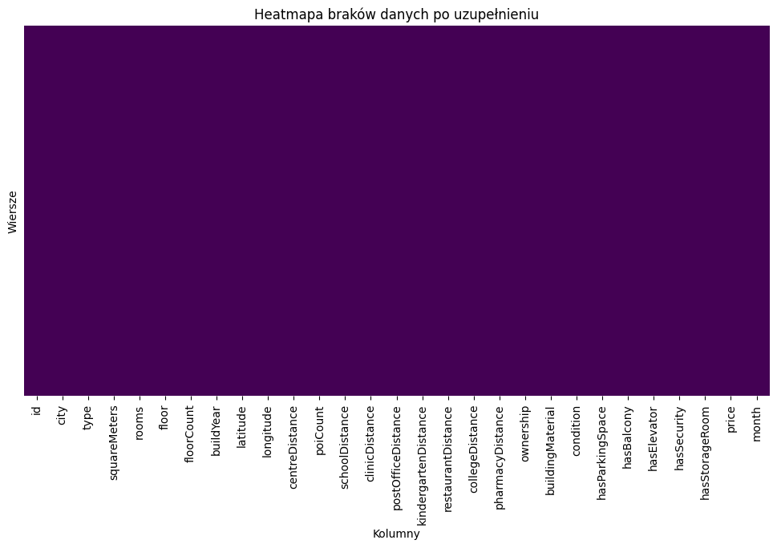

```python
plt.figure(figsize=(12, 6))

sns.heatmap(szczecin.isna(), cbar=False, yticklabels=False, cmap="viridis")

plt.title("Heatmapa braków danych po uzupełnieniu")
plt.xlabel("Kolumny")
plt.ylabel("Wiersze")

plt.show()
```

Po uzupełnieniu danych tabela braków jest pusta, co oznacza, że wszystkie brakujące wartości zostały uzupełnione.

## Sprawdzenie wartości odstających

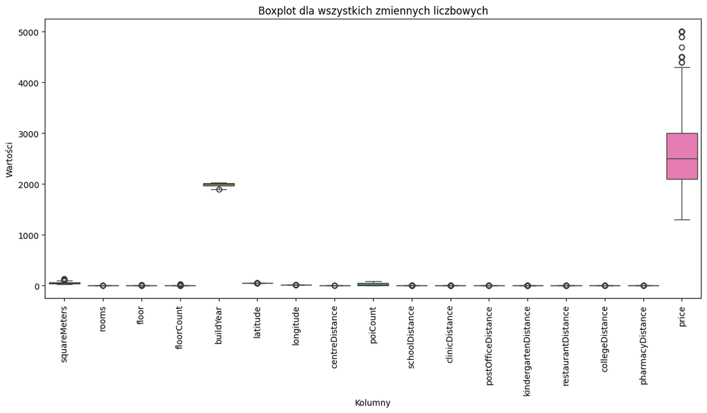

```python
kolumny_liczbowe = szczecin.select_dtypes(include=["int64", "float64"]).columns

plt.figure(figsize=(14, 6))

sns.boxplot(data=szczecin[kolumny_liczbowe])

plt.title("Boxplot dla wszystkich zmiennych liczbowych")
plt.xlabel("Kolumny")
plt.ylabel("Wartości")
plt.xticks(rotation=90)

plt.show()
```

Wykres pudełkowy pokazuje rozkład wszystkich zmiennych liczbowych oraz pojedyncze wartości odstające. Ten wykres jest jednak mało czytelny, ponieważ zmienne mają bardzo różne skale wartości. Na przykład cena najmu i rok budowy mają dużo większe wartości niż liczba pokoi, piętro czy odległości.

Z tego powodu zdecydowano się przeskalować zmienne liczbowe.

## Boxplot po przeskalowaniu zmiennych liczbowych

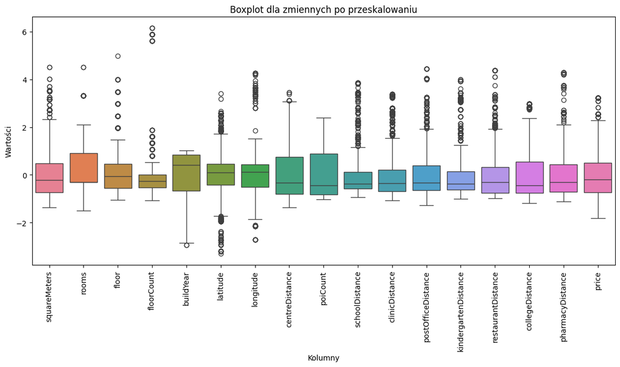

```python
dane_liczbowe = szczecin[kolumny_liczbowe]

dane_przeskalowane = (dane_liczbowe - dane_liczbowe.mean()) / dane_liczbowe.std()

plt.figure(figsize=(14, 6))

sns.boxplot(data=dane_przeskalowane)

plt.title("Boxplot dla zmiennych po przeskalowaniu")
plt.xlabel("Kolumny")
plt.ylabel("Wartości")
plt.xticks(rotation=90)

plt.show()
```

Po przeskalowaniu zmiennych liczbowych łatwiej porównać ich rozkład, ponieważ wszystkie kolumny są sprowadzone do podobnej skali. Na wykresie widać wartości odstające w kilku zmiennych, między innymi przy metrażu, liczbie pokoi, piętrze, liczbie pięter, współrzędnych oraz odległościach od różnych punktów. Nie usuwano ich, ponieważ mogą oznaczać rzeczywiste oferty, a nie błędne dane.

## Rozkład cen najmu mieszkań

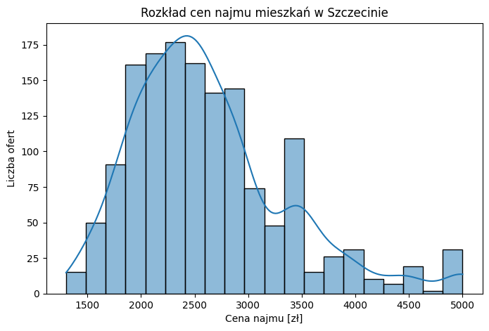

```python
plt.figure(figsize=(8, 5))

sns.histplot(data=szczecin, x="price", bins=20, kde=True)

plt.title("Rozkład cen najmu mieszkań w Szczecinie")
plt.xlabel("Cena najmu [zł]")
plt.ylabel("Liczba ofert")

plt.show()
```

Najwięcej ofert znajduje się w środkowym zakresie cen. Widać też mniej liczne oferty droższe, które tworzą prawy długi ogon rozkładu.

## Zależność ceny najmu od metrażu

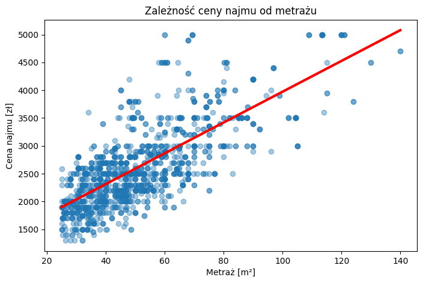

```python
plt.figure(figsize=(8, 5))

sns.regplot(
    data=szczecin,
    x="squareMeters",
    y="price",
    scatter_kws={"alpha": 0.4},
    line_kws={"color": "red", "linewidth": 3},
    ci=None
)

plt.title("Zależność ceny najmu od metrażu")
plt.xlabel("Metraż [m²]")
plt.ylabel("Cena najmu [zł]")

plt.show()
```

Wykres pokazuje zależność między metrażem mieszkania a ceną najmu.

Linia trendu wyraźnie rośnie, co oznacza, że wraz ze wzrostem metrażu rośnie też cena najmu. Najwięcej ofert znajduje się w przedziale około 30 - 60 m² i 1500 - 3000 zł. Większe mieszkania, szczególnie powyżej 80 m², częściej osiągają wyższe ceny, choć nadal widać duże zróżnicowanie.

Punkty nie układają się idealnie wzdłuż jednej linii, dlatego sam metraż nie wyjaśnia całej ceny najmu. Na cenę mogą wpływać również inne cechy, takie jak liczba pokoi, lokalizacja, standard mieszkania, balkon, winda lub miejsce parkingowe.

## Cena najmu a odległość od centrum

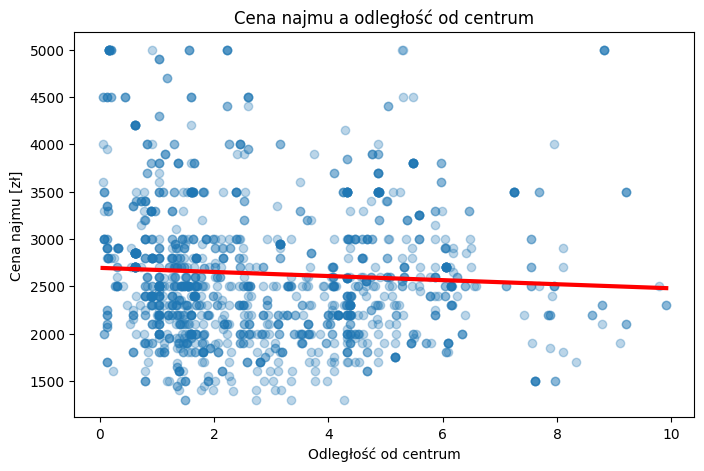

```python
plt.figure(figsize=(8, 5))

sns.regplot(
    data=szczecin,
    x="centreDistance",
    y="price",
    scatter_kws={"alpha": 0.3},
    line_kws={"color": "red", "linewidth": 3},
    ci=None
)

plt.title("Cena najmu a odległość od centrum")
plt.xlabel("Odległość od centrum")
plt.ylabel("Cena najmu [zł]")

plt.show()
```

Wykres pokazuje zależność między ceną najmu a odległością mieszkania od centrum. Każdy punkt oznacza jedną ofertę, a czerwona linia pokazuje ogólny trend.

Linia trendu jest lekko spadkowa, co sugeruje, że wraz ze wzrostem odległości od centrum cena najmu może nieznacznie maleć. Zależność nie jest jednak bardzo silna, ponieważ punkty są mocno rozproszone. Oznacza to, że na cenę wpływają też inne cechy mieszkania, takie jak metraż, liczba pokoi, standard lub dodatkowe udogodnienia.

## Liczba ofert według liczby pokoi

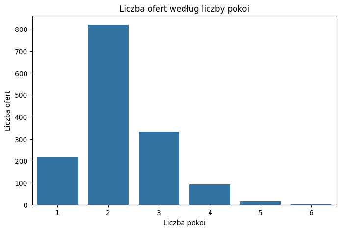

```python
plt.figure(figsize=(8, 5))

sns.countplot(data=szczecin, x="rooms")

plt.title("Liczba ofert według liczby pokoi")
plt.xlabel("Liczba pokoi")
plt.ylabel("Liczba ofert")

plt.show()
```

Wykres pokazuje, które mieszkania najczęściej pojawiają się w ofertach. Zdecydowanie dominują mieszkania dwupokojowe, drugą najliczniejszą grupę stanowią mieszkania trzypokojowe.

## Średnia cena najmu według liczby pokoi

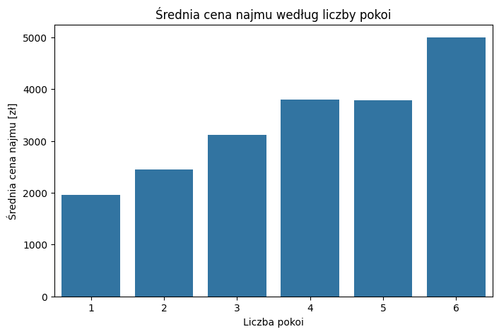

```python
cena_pokoje = szczecin.groupby("rooms")["price"].mean().reset_index()

plt.figure(figsize=(8, 5))

sns.barplot(data=cena_pokoje, x="rooms", y="price")

plt.title("Średnia cena najmu według liczby pokoi")
plt.xlabel("Liczba pokoi")
plt.ylabel("Średnia cena najmu [zł]")

plt.show()
```

Średnia cena najmu rośnie wraz z liczbą pokoi. Jest to logiczne, ponieważ mieszkania z większą liczbą pokoi charakteryzują się zazwyczaj większym metrażem.

## Liczba ofert i średnia cena w kolejnych miesiącach

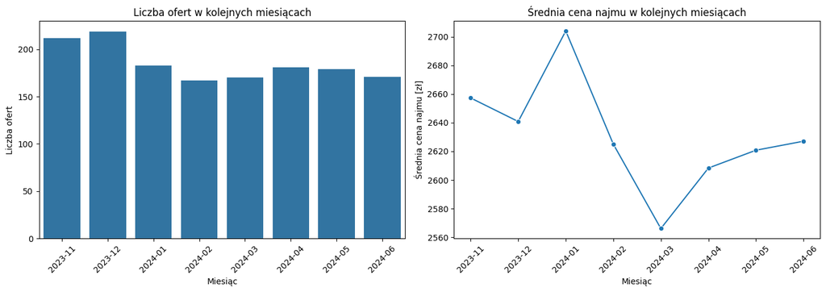

```python
miesiace = szczecin.groupby("month").agg(
    liczba_ofert=("id", "count"),
    srednia_cena=("price", "mean")
).reset_index()

fig, ax = plt.subplots(1, 2, figsize=(14, 5))

sns.barplot(data=miesiace, x="month", y="liczba_ofert", ax=ax[0])
ax[0].set_title("Liczba ofert w kolejnych miesiącach")
ax[0].set_xlabel("Miesiąc")
ax[0].set_ylabel("Liczba ofert")
ax[0].tick_params(axis="x", rotation=45)

sns.lineplot(data=miesiace, x="month", y="srednia_cena", marker="o", ax=ax[1])
ax[1].set_title("Średnia cena najmu w kolejnych miesiącach")
ax[1].set_xlabel("Miesiąc")
ax[1].set_ylabel("Średnia cena najmu [zł]")
ax[1].tick_params(axis="x", rotation=45)

plt.tight_layout()
plt.show()
```

Lewy wykres pokazuje liczbę ofert w kolejnych miesiącach. Najwięcej ofert pojawia się na początku okresu analizy, szczególnie w listopadzie i grudniu. Od stycznia 2024 liczba ofert jest niższa i utrzymuje się na bardziej zbliżonym poziomie, około 175 ofert miesięcznie.

Prawy wykres pokazuje średnią cenę najmu w kolejnych miesiącach. Najwyższa średnia cena wystąpiła w styczniu 2024 roku i wyniosła ponad 2700 zł. Następnie średnia cena spadła, osiągając najniższy poziom w marcu 2024 roku, około 2570 zł. Od kwietnia do czerwca widoczny jest lekki wzrost średniej ceny.

Na podstawie wykresu nie widać bardzo silnego trendu wzrostowego lub spadkowego w całym okresie. Ceny raczej wahają się w ograniczonym zakresie, a różnica między najwyższą i najniższą średnią ceną wynosi około 140 zł.

Zestawienie liczby ofert i średniej ceny pokazuje też, że zmiany średniej ceny nie wynikają wyłącznie z liczby dostępnych ofert. Na przykład w styczniu liczba ofert była niższa niż w grudniu, ale średnia cena była najwyższa w całym analizowanym okresie.

## Średnia cena najmu a balkon i winda

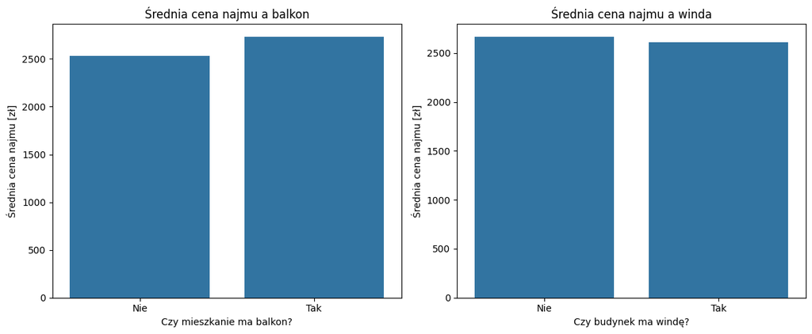

```python
cena_balkon = szczecin.groupby("hasBalcony")["price"].mean().reset_index()
cena_winda = szczecin.groupby("hasElevator")["price"].mean().reset_index()

cena_balkon["hasBalcony"] = cena_balkon["hasBalcony"].replace({
    "yes": "Tak",
    "no": "Nie"
})

cena_winda["hasElevator"] = cena_winda["hasElevator"].replace({
    "yes": "Tak",
    "no": "Nie"
})

fig, ax = plt.subplots(1, 2, figsize=(12, 5))

sns.barplot(data=cena_balkon, x="hasBalcony", y="price", ax=ax[0], order=["Nie", "Tak"])
ax[0].set_title("Średnia cena najmu a balkon")
ax[0].set_xlabel("Czy mieszkanie ma balkon?")
ax[0].set_ylabel("Średnia cena najmu [zł]")

sns.barplot(data=cena_winda, x="hasElevator", y="price", ax=ax[1], order=["Nie", "Tak"])
ax[1].set_title("Średnia cena najmu a winda")
ax[1].set_xlabel("Czy budynek ma windę?")
ax[1].set_ylabel("Średnia cena najmu [zł]")

plt.tight_layout()
plt.show()
```

Mieszkania z balkonem mają wyższą średnią cenę najmu niż mieszkania bez balkonu. W przypadku windy różnica jest niewielka - średnia cena mieszkań w budynkach z windą jest bardzo podobna do mieszkań bez windy.

## Wnioski końcowe

W projekcie przeanalizowano oferty wynajmu mieszkań w Szczecinie z okresu od listopada 2023 do czerwca 2024. Dane zostały połączone z kilku plików miesięcznych, a następnie ograniczone do jednego miasta.

W danych nie znaleziono duplikatów. Zauważono jednak, że część ofert pojawiała się w więcej niż jednym miesiącu, ponieważ liczba unikalnych identyfikatorów ofert była mniejsza niż liczba wszystkich obserwacji. Nie potraktowano tego jako błędu, ponieważ analiza obejmuje dane z kilku miesięcy.

Braki danych występowały głównie w kolumnach opisujących cechy mieszkania i budynku, takich jak stan mieszkania, typ mieszkania, materiał budynku, rok budowy, piętro oraz obecność windy. Braki zostały uzupełnione metodą hot deck. Po uzupełnieniu liczba braków wyniosła 0.

Wizualizacje pokazały, że najwięcej ofert znajduje się w środkowym zakresie cen, a droższe mieszkania tworzą prawy ogon rozkładu. Widać również dodatnią zależność między metrażem a ceną najmu - większe mieszkania zazwyczaj są droższe.

Najwięcej ofert dotyczy mieszkań dwupokojowych i trzypokojowych. Średnia cena najmu rośnie wraz z liczbą pokoi, co jest zgodne z intuicją, ponieważ większa liczba pokoi zwykle oznacza większy metraż.

Analiza miesięczna pokazała, że liczba ofert była najwyższa na początku analizowanego okresu, a średnia cena najmu osiągnęła najwyższy poziom w styczniu 2024 roku. W kolejnych miesiącach ceny wahały się, ale nie było bardzo silnego trendu wzrostowego lub spadkowego.

Porównanie mieszkań z balkonem i bez balkonu pokazało, że mieszkania z balkonem mają wyższą średnią cenę najmu. W przypadku windy różnica była niewielka.